# Functional categories of mutated host genes

Daniel Schwartz

2022-10-04

In a previous analysis we found that there is a difference in the rank-multiplicity distribution of genes between populations with vs. without seed banks.

[figure not shown]

We now ask if there are functional categories that are enriched in the genes mutated in each population, separating the genes between the top ranked genes and the genes in the tail (found only in seed bank populations.

### Focus on high level Subtiwiki categories

recreate RAC plot

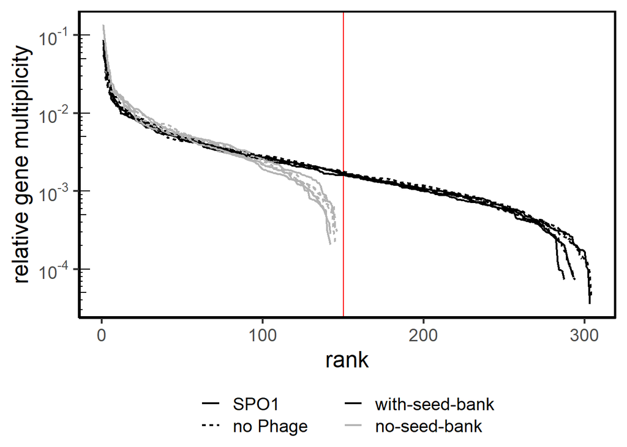

```r
sw_rank %>%
  filter(!is.na(rank)) %>%
  ggplot(aes(x= rank, y = mult)) +
  geom_vline(xintercept = 150, color = "red")+
  geom_line(aes(group = interaction(seed.bank,phage,replicate_pop),
                color = seed.bank,
                linetype = phage), size = 0.8)+
  theme_classic(base_size = 18)+
  panel_border(color = "black", size = 1.5)+
  scale_y_log10(labels = trans_format("log10", math_format(10^.x)),
                # limits = c(1e-5, NA)
                )+
  scale_color_grey(start = 0, end = 0.7)+
  annotation_logticks(sides = "l")+
  ylab("relative gene multiplicity")+
  theme(legend.position = "bottom",#c(0.7, 0.8),
        legend.direction = "vertical",
      legend.title = element_blank(),
      legend.background = element_blank(),
      legend.margin = margin(t=-10,b=0,l=5,r=5))
```

```r
sw_rank <- sw_rank %>%
  # mark if left or right side of the distribution
  mutate(LR = if_else(rank<=150, "left", "right")) %>%
  mutate(phage = if_else(phage=="SPO1", "with-phage","without-phage"))
```

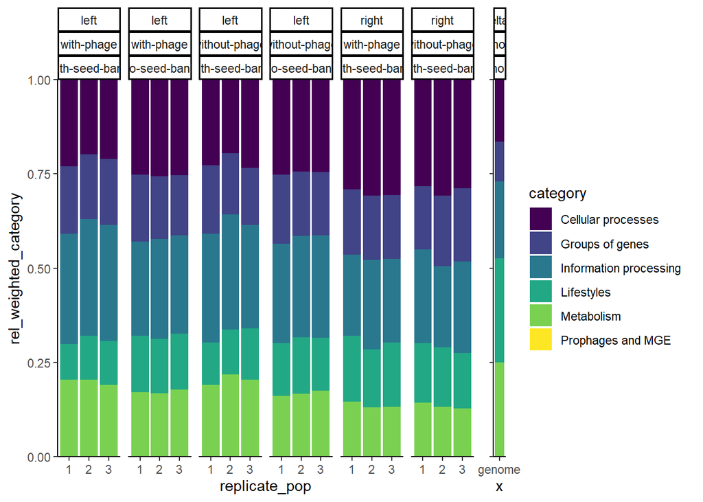

```r
p.observed <- sw_rank %>%
  mutate(category = as_factor(category)) %>%
  filter(!is.na(rank)) %>%
  # relative abundance
  group_by(LR, seed.bank, phage, replicate_pop) %>%
  mutate(rel_weighted_category = weighted_category/sum(weighted_category)) %>%
  ggplot(aes(replicate_pop, rel_weighted_category))+
  geom_col(aes(fill = category), show.legend = F)+
  scale_fill_viridis_d(drop = F)+
  facet_wrap(LR+phage ~ seed.bank, nrow = 1)+
  theme_classic()+
  scale_y_continuous(limits = c(0,1), expand = c(0, 0))


p.expected <-
  categories_delta6 %>%
  mutate(category = str_replace(category,"mobile genetic elements", "MGE")) %>%
  group_by(category) %>%
  summarise(weighted_category = sum(n_category)) %>%
  ungroup() %>%
  # relative abundance
  mutate(rel_weighted_category = weighted_category/sum(weighted_category)) %>%
  ggplot(aes("genome", rel_weighted_category))+
  geom_col(aes(fill = category), show.legend = T)+
  scale_fill_viridis_d()+
  facet_wrap("delta6" ~ "whole" + "genome", nrow = 1)+
  theme_classic()+
  theme(axis.title.y = element_blank(),
        axis.text.y = element_blank())+
  scale_y_continuous(limits = c(0,1), expand = c(0, 0))

plot_grid(p.observed, p.expected, rel_widths = c(12, 5.5), nrow = 1)
```

### Test if gene categories are representation of genome categories

Using chi-square test observed vs expected

```r
# Expected category distribution
# categories in whole genome
expected_delta6 <-
  categories_delta6 %>%
  mutate(weighted_category = 1/n_category) %>%
  group_by(category.id, category) %>%
  summarise(expected = sum(weighted_category))
observed <-
  sw_rank %>%
  group_by(category.id, category, replicate_pop, phage, seed.bank, LR) %>%
  summarise(observed = sum(weighted_category)) %>%
  ungroup()
```

```
## 'phage', 'seed.bank'. You can override using the `.groups` argument.
```

```r
# chi-square Observed vs. expected
d.chi <- tibble()

for(sb in unique(observed$seed.bank)){
  for (phg in unique(observed$phage)){
    for (pop in unique(observed$replicate_pop)){
      for (lr in unique(observed$LR)){
       cur_d <-
      observed %>%
      filter( seed.bank == sb &
              phage == phg &
              replicate_pop==pop &
              LR == lr  ) %>%
        select(category.id, observed) %>%
        left_join(expected_delta6,., by = "category.id") %>%
        mutate(observed = replace_na(observed, 0))

       if(sum(cur_d$observed)==0) next

      d.chi <-
        bind_cols(tibble(LR=lr , seed.bank = sb,
                         phage = phg, replicate_pop=pop),
                  chisq.test(cur_d$observed,p =cur_d$expected,
                             rescale.p = T) %>% tidy()) %>%
        bind_rows(d.chi, .)
      }
    }
  }
}


d.chi %>%
  mutate(p.adj = p.adjust(p.value, method = "BH")) %>%
  arrange(p.value)
```

```
## # A tibble: 18 x 9
##    LR    seed.bank  phage replicate_pop statistic p.value parameter method p.adj
##    <chr> <chr>      <chr> <chr>             <dbl>   <dbl>     <dbl> <chr>  <dbl>
##  1 right with-seed~ with~ 3                15.0    0.0103         5 Chi-s~ 0.114
##  2 right with-seed~ with~ 2                13.4    0.0197         5 Chi-s~ 0.114
##  3 right with-seed~ with~ 2                13.3    0.0211         5 Chi-s~ 0.114
##  4 right with-seed~ with~ 1                12.8    0.0254         5 Chi-s~ 0.114
##  5 right with-seed~ with~ 1                10.1    0.0717         5 Chi-s~ 0.240
##  6 right with-seed~ with~ 3                 9.84   0.0798         5 Chi-s~ 0.240
##  7 left  no-seed-b~ with~ 2                 4.47   0.484          5 Chi-s~ 0.938
##  8 left  no-seed-b~ with~ 2                 4.37   0.497          5 Chi-s~ 0.938
##  9 left  no-seed-b~ with~ 1                 4.21   0.520          5 Chi-s~ 0.938
## 10 left  no-seed-b~ with~ 3                 4.20   0.521          5 Chi-s~ 0.938
## 11 left  no-seed-b~ with~ 1                 3.80   0.579          5 Chi-s~ 0.947
## 12 left  no-seed-b~ with~ 3                 3.20   0.670          5 Chi-s~ 0.977
## 13 left  with-seed~ with~ 3                 2.71   0.744          5 Chi-s~ 0.977
## 14 left  with-seed~ with~ 2                 2.53   0.772          5 Chi-s~ 0.977
## 15 left  with-seed~ with~ 2                 2.18   0.823          5 Chi-s~ 0.977
## 16 left  with-seed~ with~ 3                 1.85   0.870          5 Chi-s~ 0.977
## 17 left  with-seed~ with~ 1                 0.987  0.964          5 Chi-s~ 0.977
## 18 left  with-seed~ with~ 1                 0.804  0.977          5 Chi-s~ 0.977
```

Category proportions for genes in the left-hand side of the distribution are clearly no different than the whole genome proportions. However, genes on the right-hand side are hovering around the significance threshold in this test, if we consider the un-adjusted p-value.

## post hoc

I want to see if there is any specific category of genes driving the results of test above for gene on the right-hand side of the distribution. To address this I will use a binomial test to test if the proportion of genes in each category in each sample, deviate from the whole genome proportion.

```r
# add whole genome proportions
expected_delta6 <- expected_delta6 %>%
  mutate(p.exp= expected/sum(.$expected))

# focus on right0hannd side genes
obs_right <- observed %>%
  filter(LR == "right")

d_test <- obs_right %>%
  #binomial requires integers
  mutate(r_obs = round(observed)) %>%
  # sum for sample proportions
  group_by(seed.bank,phage, replicate_pop) %>%
  summarise(n_sample = sum(r_obs)) %>%
  left_join(obs_right,.) %>%
  #binomial requires integers
   mutate(r_obs = round(observed)) %>%
  # add expected proportion
  left_join(., expected_delta6) %>%
  ungroup()
# for each sample and each category, do binomial test
for(i in 1:nrow(d_test)){
  d_test$pval[i] <-
    binom.test(x = d_test$r_obs[i],
               n = d_test$n_sample[i],
               p = d_test$p.exp[i])$p.value


}
# multiple testing adjustment
d_test$p.adj <- p.adjust(d_test$pval, method = "BH")
d_test %>% arrange(p.adj)
```

```
## # A tibble: 30 x 13
##    category.id category    replicate_pop phage seed.bank LR    observed n_sample
##    <chr>       <chr>       <chr>         <chr> <fct>     <chr>    <dbl>    <dbl>
##  1 SW.1        Cellular p~ 1             with~ with-see~ right     23.9      137
##  2 SW.1        Cellular p~ 3             with~ with-see~ right     24.2      143
##  3 SW.2        Metabolism  2             with~ with-see~ right     47.1      153
##  4 SW.2        Metabolism  2             with~ with-see~ right     44.2      144
##  5 SW.2        Metabolism  3             with~ with-see~ right     43.9      143
##  6 SW.6        Groups of ~ 2             with~ with-see~ right     20        153
##  7 SW.6        Groups of ~ 2             with~ with-see~ right     19        144
##  8 SW.6        Groups of ~ 3             with~ with-see~ right     19        143
##  9 SW.6        Groups of ~ 3             with~ with-see~ right     19        149
## 10 SW.1        Cellular p~ 1             with~ with-see~ right     24.5      154
## # ... with 20 more rows, and 5 more variables: r_obs <dbl>, expected <dbl>,
## #   p.exp <dbl>, pval <dbl>, p.adj <dbl>
```

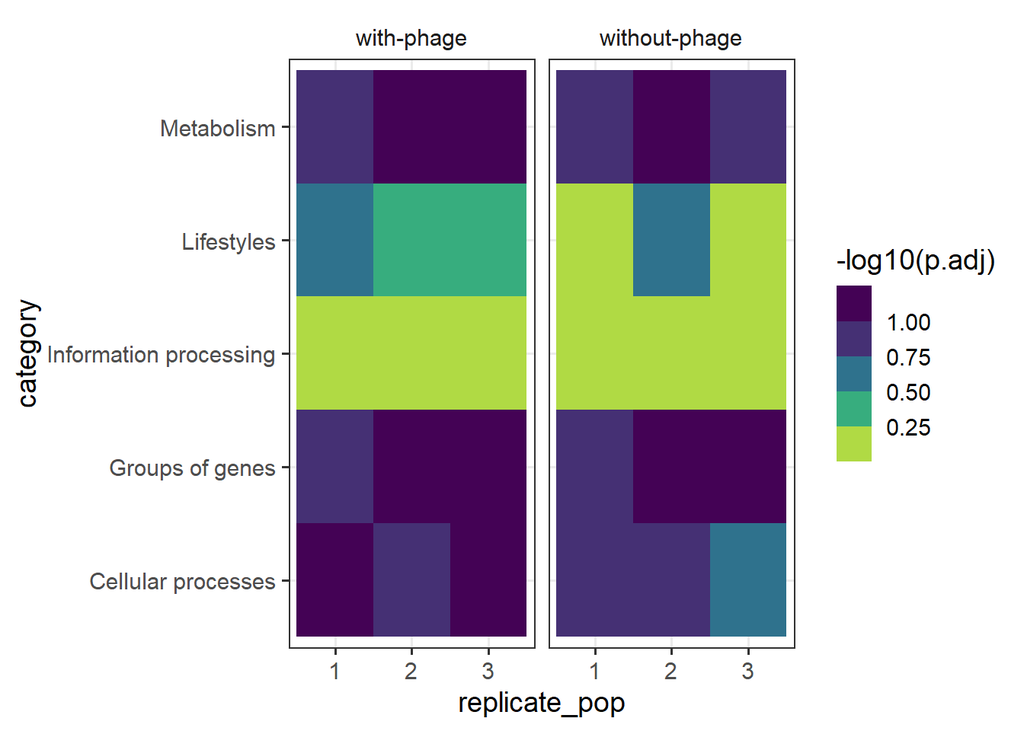

```r
d_test %>%
  ggplot(aes(replicate_pop, category)) +
  geom_tile(aes(fill = -log10(p.adj)))+
  facet_wrap(~phage)+
  scale_fill_viridis_b(direction = -1)+
  theme_bw(base_size = 14)+
  theme(strip.background = element_blank())
```

All are non-significant. Next plot is to look at the direction of change.

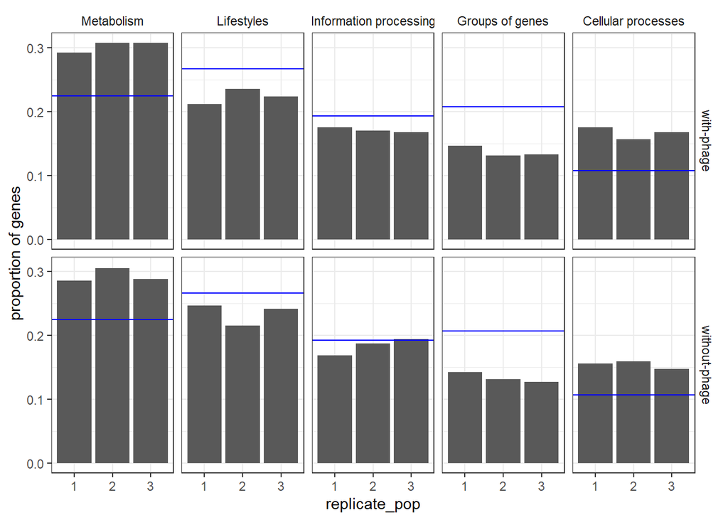

```r
d_test %>%
  # filter(category == "Information processing") %>%
  ggplot(aes(replicate_pop, y=r_obs/n_sample))+
  geom_col()+
  geom_hline(aes(yintercept = p.exp), color = "blue")+
  facet_grid(phage ~ category %>% fct_rev())+
  scale_fill_viridis_b()+
  theme_bw()+
  theme(strip.background = element_blank())+
  ylab("proportion of genes")
```